# factor_analysis

### 주성분 요인분석 2. Varimax 회전

- Varimax 회전한 주성분 요인분석을 하시오.

```r
# varimax 회전
Mfapcvmx <- principal(X, nfactor=3, rotate='varimax')
print(Mfapcvmx, digits=4)
```

```
## Principal Components Analysis
## Call: principal(r = X, nfactors = 3, rotate = "varimax")
## Standardized loadings (pattern matrix) based upon correlation matrix
##         RC1     RC2     RC3     h2     u2   com
## Q01 -0.0986  0.5651  0.3944 0.4847 0.5153 1.860
## Q02 -0.1559  0.4988  0.2252 0.3238 0.6762 1.612
## Q03  0.1699  0.5811  0.2339 0.4212 0.5788 1.506
## Q04  0.4585  0.2555  0.0417 0.2772 0.7228 1.586
## Q05  0.3623  0.3451 -0.0849 0.2576 0.7424 2.108
## Q06  0.2811  0.3099  0.2967 0.2631 0.7369 2.981
## Q07  0.3063  0.0460  0.4489 0.2974 0.7026 1.791
## Q08  0.3671  0.5856  0.0011 0.4777 0.5223 1.681
## Q09  0.5447  0.2307  0.0889 0.3579 0.6421 1.408
## Q10  0.5909 -0.1962  0.2056 0.4299 0.5701 1.477
## Q11  0.6358 -0.1540  0.1322 0.4455 0.5545 1.208
## Q12  0.7634  0.1617  0.0046 0.6089 0.3911 1.090
## Q13  0.5593  0.1170  0.2453 0.3867 0.6133 1.471
## Q14  0.0749  0.1354  0.7745 0.6238 0.3762 1.080
## Q15  0.0388  0.0751  0.8268 0.6907 0.3093 1.021
## Q16  0.1917 -0.0562  0.7049 0.5368 0.4632 1.161
## Q17  0.1431  0.6639 -0.0171 0.4615 0.5385 1.094
## Q18  0.0296  0.6580 -0.1485 0.4558 0.5442 1.106
##
##                          RC1    RC2    RC3
## SS loadings           2.7228 2.5874 2.4900
## Proportion Var        0.1513 0.1437 0.1383
## Cumulative Var        0.1513 0.2950 0.4333
## Proportion Explained  0.3491 0.3317 0.3192
## Cumulative Proportion 0.3491 0.6808 1.0000
##
## Mean item complexity =  1.5
## Test of the hypothesis that 3 components are sufficient.
##
## The root mean square of the residuals (RMSR) is  0.0953
##  with the empirical chi square  280.7195  with prob <  1.289e-18
##
## Fit based upon off diagonal values = 0.8034
```

```r
# 회전 후 요인행렬
print(fa.sort(Mfapcvmx), cut=0.4, digits=4)
```

```
## Principal Components Analysis
## Call: principal(r = X, nfactors = 3, rotate = "varimax")
## Standardized loadings (pattern matrix) based upon correlation matrix
##         RC1     RC2     RC3     h2     u2   com
## Q12  0.7634                 0.6089 0.3911 1.090
## Q11  0.6358                 0.4455 0.5545 1.208
## Q10  0.5909                 0.4299 0.5701 1.477
## Q13  0.5593                 0.3867 0.6133 1.471
## Q09  0.5447                 0.3579 0.6421 1.408
## Q04  0.4585                 0.2772 0.7228 1.586
## Q05                         0.2576 0.7424 2.108
## Q17          0.6639         0.4615 0.5385 1.094
## Q18          0.6580         0.4558 0.5442 1.106
## Q08          0.5856         0.4777 0.5223 1.681
## Q03          0.5811         0.4212 0.5788 1.506
## Q01          0.5651         0.4847 0.5153 1.860
## Q02          0.4988         0.3238 0.6762 1.612
## Q06                         0.2631 0.7369 2.981
## Q15                  0.8268 0.6907 0.3093 1.021
## Q14                  0.7745 0.6238 0.3762 1.080
## Q16                  0.7049 0.5368 0.4632 1.161
## Q07                  0.4489 0.2974 0.7026 1.791
##
##                          RC1    RC2    RC3
## SS loadings           2.7228 2.5874 2.4900
## Proportion Var        0.1513 0.1437 0.1383
## Cumulative Var        0.1513 0.2950 0.4333
## Proportion Explained  0.3491 0.3317 0.3192
## Cumulative Proportion 0.3491 0.6808 1.0000
##
## Mean item complexity =  1.5
## Test of the hypothesis that 3 components are sufficient.
##
## The root mean square of the residuals (RMSR) is  0.0953
##  with the empirical chi square  280.7195  with prob <  1.289e-18
##
## Fit based upon off diagonal values = 0.8034
```

- fa.diagram을 이용하여 요인적재량을 시각화하시오. 요인적재량이 다수의 요인에 걸리는 문항이 있는지 확인(cut을 0.5이하 여러가지 값을 시도해볼 것)

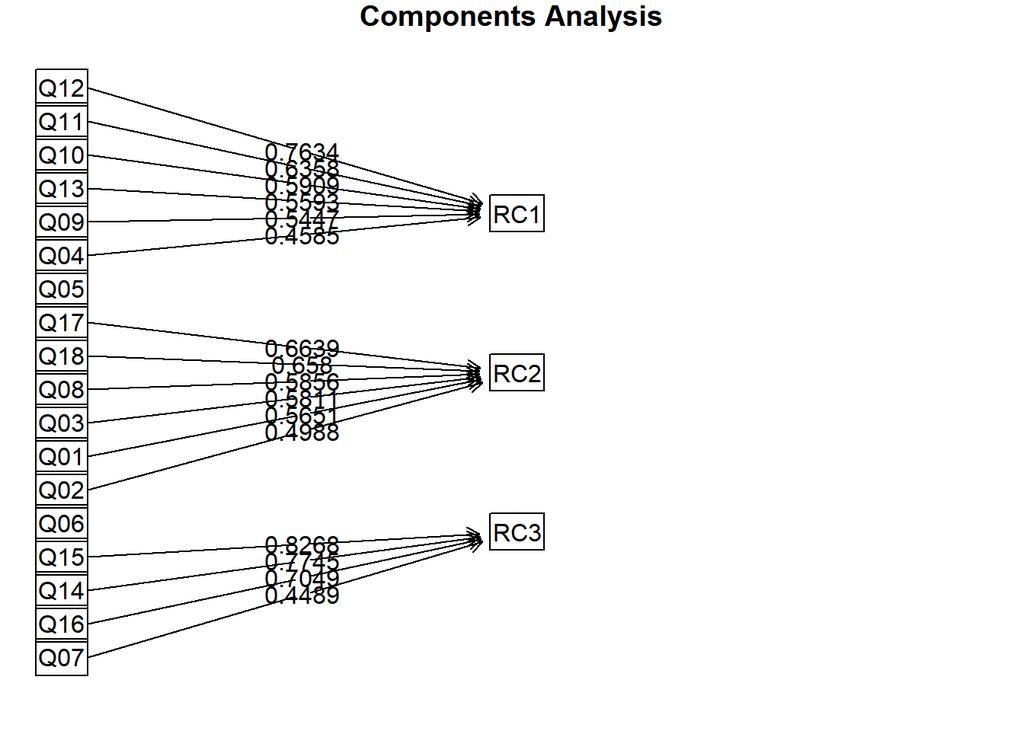

```r
fa.diagram(Mfapcvmx, simple=FALSE, cut=0.4, digits=4)
```

- biplot으로 회전이 적절한지 확인하시오

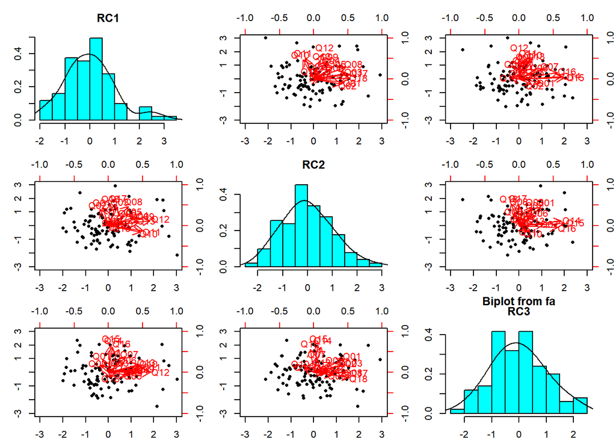

```r
biplot(Mfapcvmx)
```